# Data Summary of Airbnb Listings in Sydney

Project 1

490357040, 490481703, 490411445, 490417311

University of Sydney | DATA1901 | Monday 12:00pm Lab 705-706 | August 2019

# 1 Executive Summary

The primary aim of this report is to uncover, if present, any associations between Sydney Airbnb accommodation prices and their corresponding geographic location. A secondary aim it to ask the same question for room type and the minimum nights a customer must stay.

The main discoveries include:

- Prices per night are higher within a 10km range of the CBD and Northern Beaches;
- Prices per night are lower when the distance is greater than 40km from the CBD;
- Entire home listings generally require a higher minimum nights of stay; and
- Shared room and private room listings share similar trends in minimum night requirements.

# 2 Full Report

## 2.1 Initial Data Analysis

### 2.1.1 Data Source

The dataset used to produce this report has been sourced from the website [Inside Airbnb](http://insideairbnb.com/index.html). Inside Airbnb scrapes publicly available information from Airbnb to provide monthly point in time datasets for a range of cities around the world. This report uses the July 2019 dataset for Sydney, which is treated as a sample for Sydney’s Airbnb listings in general.

### 2.1.2 Data Reliability and Limitations

Readers should be aware that the datasets provided by Inside Airbnb do not constitute the primary datasets held by Airbnb. The process of web scraping may introduce errors in coding or interpretation, or deliberate tampering of observations. Further analyses may benefit from seeking primary data from Airbnb itself. Nonetheless, as a readily available dataset it is still a useful resource for conducting exploratory analyses.

### 2.1.4 Stakeholders

Potential stakeholders include:

- **Property owners** considering listing on Airbnb who are unsure of the price and minimum nights to set given their location and room type.
- **Local or State Governments** who are interested in comparing listing prices and rental markets at given locations.
- **Current hosts** who are interested in the competitiveness of their listing against similar listings. **Hotel chains** may be interested for similar reasons.

```r
#IDA
class(listingOriginal)
## [1] "data.frame"
head(listingOriginal)
##      id                                              name host_id
## 1 11156                              An Oasis in the City   40855
## 2 12351                 Sydney City & Harbour at the door   17061
## 3 14250                               Manly Harbour House   55948
## 4 15253 Stunning Penthouse Apartment In Heart Of The City   59850
## 5 20865                3 BED HOUSE + 1 BED STUDIO Balmain   64282
## 6 26174                COZY PRIVATE ROOM, GREAT LOCATION!  110561
##   host_name neighbourhood_group neighbourhood  latitude longitude
## 1   Colleen                  NA        Sydney -33.86917  151.2266
## 2    Stuart                  NA        Sydney -33.86515  151.1919
## 3     Heidi                  NA         Manly -33.80093  151.2617
## 4     Morag                  NA        Sydney -33.88045  151.2165
## 5     Fiona                  NA    Leichhardt -33.85907  151.1728
## 6    Amanda                  NA     Woollahra -33.88909  151.2594
##         room_type price minimum_nights number_of_reviews last_review
## 1    Private room    65              2               185  2019-04-24
## 2    Private room 14316              2               516  2019-06-29
## 3 Entire home/apt   470              5                 2  2019-01-02
## 4    Private room   110              2               323  2019-05-23
## 5 Entire home/apt   450              7                16  2019-01-03
## 6    Private room    62              1                45  2019-03-29
##   reviews_per_month calculated_host_listings_count availability_365
## 1              1.58                              1              354
## 2              4.73                              2               19
## 3              0.05                              2               99
## 4              3.60                              3              336
## 5              0.17                              1              142
## 6              0.45                              1              181
dim(listingOriginal)
## [1] 38080    16
str(listingOriginal)
## 'data.frame':    38080 obs. of  16 variables:
##  $ id                            : int  11156 12351 14250 15253 20865 26174 38073 39348 44545 57183 ...
##  $ name                          : Factor w/ 37244 levels ""," Bondi-Park side 2 storey House 3br",..: 3234 33849 20828 31788 1819 12087 21845 18121 32863 6699 ...
##  $ host_id                       : int  40855 17061 55948 59850 64282 110561 103476 168828 112237 1623151 ...
##  $ host_name                     : Factor w/ 8207 levels "","(Christine)Jianhua",..: 1454 6962 2793 5164 2298 296 5856 4711 659 7021 ...
##  $ neighbourhood_group           : logi  NA NA NA NA NA NA ...
##  $ neighbourhood                 : Factor w/ 38 levels "Ashfield","Auburn",..: 33 33 21 33 19 38 24 36 33 36 ...
##  $ latitude                      : num  -33.9 -33.9 -33.8 -33.9 -33.9 ...
##  $ longitude                     : num  151 151 151 151 151 ...
##  $ room_type                     : Factor w/ 3 levels "Entire home/apt",..: 2 2 1 2 1 2 1 1 1 1 ...
##  $ price                         : int  65 14316 470 110 450 62 159 85 130 174 ...
##  $ minimum_nights                : int  2 2 5 2 7 1 2 5 3 4 ...
##  $ number_of_reviews             : int  185 516 2 323 16 45 63 10 60 129 ...
##  $ last_review                   : Factor w/ 1581 levels "","2012-01-06",..: 1504 1570 1392 1533 1393 1478 920 1394 1469 1561 ...
##  $ reviews_per_month             : num  1.58 4.73 0.05 3.6 0.17 0.45 0.6 0.67 0.56 1.24 ...
##  $ calculated_host_listings_count: int  1 2 2 3 1 1 2 1 1 1 ...
##  $ availability_365              : int  354 19 99 336 142 181 187 8 52 94 ...
```

```r
# Classification of variables of interest for report
sapply(listingOriginal[c(1,6,7,8,9,10,11)], class)
```

```
##             id  neighbourhood       latitude      longitude      room_type
##      "integer"       "factor"      "numeric"      "numeric"       "factor"
##          price minimum_nights
##      "integer"      "integer"
```

## 2.2 Research Question 1

> Is there an association between the price of an Airbnb listing in Sydney and its geographical location with respect to the central business district (CBD)?

The global online accommodation platform, Airbnb, has experienced an exponential growth in listings and prices throughout Sydney’s metropolitan and suburban areas. Costs of accommodation have been rising dramatically in parallel with increasing tourism figures, which counted 32.5 million visits in 2013-14 (Gurran & Phibbs 2017). Consequently, tourists have been branching out from traditional beachside and CBD destinations into more residential areas (Figure 1). Despite this migration, our analyses show that prices still peak in popular metropolitan and coastal suburbs.

[figure not shown]

<sup>**Figure 1. Map of Airbnb price hotspots across Sydney**</sup>

```r
###  code for map plot - Origin at Sydney CBD

airbnb <- read.csv("http://data.insideairbnb.com/australia/nsw/sydney/2019-07-10/visualisations/listings.csv")

uppermult <- 50 #multliplier for upper limit of price (multiple of IQR)
lowermult <- 5 #multliplier for lower limit of price (multiple of IQR)

airbnb_filt <- airbnb[airbnb$price < IQR(airbnb$price)*uppermult & airbnb$price > IQR(airbnb$price)*lowermult, ]
#change the room type as well ("Private room, Entire home/apt, Shared room)  & (airbnb$room_type == "Entire home/apt")

ggmap::register_google(key = "AIzaSyA-F-AjHoFsbSRX-ehJBl0rbrTkdpCiFbU")

#NOTE: for the map we probably should restrict the price variables otherwise the entire map is dominated by one colour (there are a lot of 'low price' points)
m <- ggmap(get_googlemap(center = c(lon = 151.2, lat = -33.8),  maptype ='terrain', zoom = 10))
m + geom_point(data = airbnb_filt, aes(x = longitude, y = latitude, colour = price, alpha=price, size=price)) + #maybe make the soze the price factor???
  xlab("Longitude") + ylab("Latitude") +
  theme(legend.position="right") +
  labs(colour = "Price ($)") +
  labs(alpha = "Price ($)", size = "Price($)") +
  theme(axis.title.y = element_text(margin = margin(t = 0, r = 10, b = 0, l = 0))) +
  theme(axis.title.x = element_text(margin = margin(t = 10, r = 0, b = 20, l = 0))) +
  scale_colour_gradient(low = "#FEC804", high = "#9c4376") # change the gradient colours
```

An initial investigation (Figure 2) shows that the price variable, representing the price per night for a listing, is heavily right-skewed (*Md* = $130, *$\bar{x}$* = $206, *s* = $389). The ‘hot spots’ are found within 10km of the CBD and the Northern Beaches (30km north of the CBD), while prices steadily decline into suburban areas (40km west of the CBD).

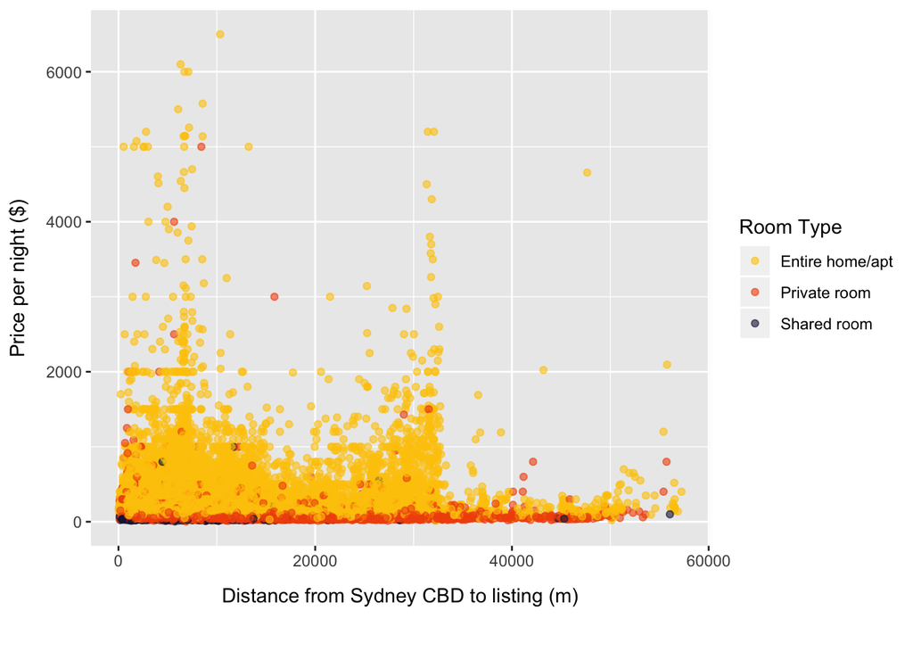

<sup>**Figure 2. Scatterplot of price per night in dollars against distance from listing to Sydney CBD in metres.**</sup>

```r
### code for scatterplot
ggmap::register_google(key = "AIzaSyD6iGtQgCyA3ds1kSzPh7mMDyMoIVriVU4")

lat <- airbnb$latitude
long <- airbnb$longitude

#syd(-33.8708, 151.2073)
#chatswood (-33.7961, 151.1780)
#parramatta (-33.8136, 151.0034)
#central coast (-33.3208, 151.2336)
#northern beaches (-33.6892, 151.2685)
#palm beach (-33.6011, 151.3217)
#bigola beach (-33.6445, 151.3276)

#change the latitude and longitude coordinates to change the origin
Loc_lat <- -33.8708
Loc_long <- 151.2073
location = "Sydney CBD"

price <- airbnb$price

if (length(lat) != length(long)){
  quit("length of lat and long column is not the same")
}


dist <- vector(mode="numeric", length = length(long))

for (i in 1:length(long)){
  dist[i] <- distHaversine(c(Loc_long, Loc_lat), c(long[i], lat[i]))

}

airbnb$Distance_from_origin <- dist

uppermult <- 50 #multliplier for upper limit of price (multiple of IQR)
lowermult <- 0 #multliplier for lower limit of price (multiple of IQR)

airbnb_filt <- airbnb[airbnb$price < IQR(airbnb$price)*uppermult & airbnb$price > IQR(airbnb$price)*lowermult, ]
#change the room type as well ("Private room, Entire home/apt, Shared room)  & (airbnb$room_type == "Entire home/apt")


#Scatter plot
g <- ggplot(data = airbnb_filt, aes(x=Distance_from_origin, y = price, colour = room_type)) +
  theme(axis.title.y = element_text(margin = margin(t = 0, r = 10, b = 0, l = 0))) +
  theme(axis.title.x = element_text(margin = margin(t = 10, r = 0, b = 20, l = 0))) +
  xlab(paste("Distance from",location,"to listing (m)", sep=" ")) +
  ylab("Price per night ($)") +
  labs(colour = "Room Type") +
  geom_point(alpha = 0.6) +
  scale_color_manual(values = colPaletteDark)
g
```

These findings are not surprising. Tourists are drawn in by attractions such as the Opera House and Bondi Beach, while residents are attracted to employment/business opportunities and public transport access. In short, as proximity to recreational areas and key attractions increases, intuitively, so too does the value and consequent asking price of a listing. Similarly, the Northern Beaches is imaged as an exclusive, desirable location, with highly accessible recreational areas and beaches. As a result these listings experience high demand, and can ask for high per night prices (*Md* = $450, *$\bar{x}$* = $654, *s* = $667). In opposition, suburban listings request significantly lower prices (*Md* = $120, *$\bar{x}$* = $190, *s* = $353). This may be due to various factors, such as a less dense residential population, or limited access to facilities, tourist attractions and international airports (Burnley & Murphy, 2013).

In summary we find that there is an association between the price of a listing and its geographical location. However this association is not limited to the CBD, but encompasses coastal hotspots also.

```r
###numerical analysis

#Sydney CBD values
price <- airbnb$price
dist <- airbnb$Distance_from_origin

mean_dataset = mean(price)
mean_dataset
## [1] 205.8083
median_dataset = median(price)
median_dataset
## [1] 130
sd_dataset = sd(price)
sd_dataset
## [1] 389.1984

mean_syd5km = mean(price[dist < 5000])
mean_syd5km
## [1] 189.5683
median_syd5km = median(price[dist < 5000])
median_syd5km
## [1] 135
sd_syd5km = sd(price[dist < 5000])
sd_syd5km
## [1] 443.6522


### Northern beaches values
airbnb1 <- airbnb #this dataset will have the origin at Palm beach (for the distance column)


Loc_lat <- -33.6011
Loc_long <- 151.3217
location = "Palm Beach (Northern Beaches)"

price1 <- airbnb1$price
lat <- airbnb1$latitude
long <- airbnb1$longitude

if (length(lat) != length(long)){
  quit("length of lat and long column is not the same")
}


dist1 <- vector(mode="numeric", length = length(long))

for (i in 1:length(long)){
  dist1[i] <- distHaversine(c(Loc_long, Loc_lat), c(long[i], lat[i]))

}

airbnb1$Distance_from_origin <- dist1

mean_north5km = mean(price1[dist1 < 5000])
mean_north5km
## [1] 654.205
median_north5km = median(price1[dist1 < 5000])
median_north5km
## [1] 450
sd_north5km = sd(price1[dist1 < 5000])
sd_north5km
## [1] 666.8867

### Suburban values
mean_suburbs = mean(price[dist > 40000])
mean_suburbs
## [1] 190.2642
median_suburbs = median(price[dist > 40000])
median_suburbs
## [1] 120
sd_suburbs = sd(price[dist > 40000])
max(price[dist > 40000])
## [1] 4656
sd_suburbs
## [1] 353.2877
```

```r
### code to find the percentage of listings within a n 8km radius of the origin

#density around CBD
dist_origin <- airbnb$Distance_from_origin
cluster = airbnb[dist_origin < 8000, ]
size_cluster = dim(cluster)[1]
size_cluster
## [1] 25125
size_airbnb = dim(airbnb)[1]
perc_listings = (size_cluster/size_airbnb)*100
perc_listings
## [1] 65.97952
```

## 2.3 Research Question 2

> Is there any association between the minimum number of nights required for a booking and the type of room available for an Airbnb listing in Sydney?

Like price, the minimum_night variable is heavily right-skewed, including two listings that require a minimum stay of 1000 nights (Figure 3).

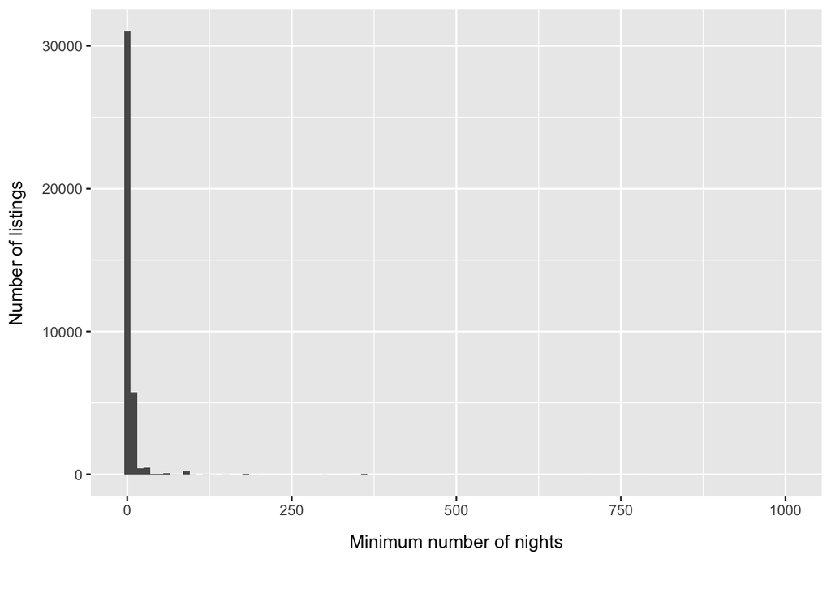

<sup>**Figure 3. Count of listings by minimum number of nights required. Includes all observations.**</sup>

```r
## create histogram of min nights for all observations
minNightsAll = ggplot(listingOriginal, aes(x = minimum_nights))
minNightsAll +
  geom_histogram(binwidth = 10) +
  theme(axis.title.y = element_text(margin = margin(t = 0, r = 10, b = 0, l = 0))) +
  theme(axis.title.x = element_text(margin = margin(t = 10, r = 0, b = 20, l = 0))) +
  xlab(paste("Minimum number of nights")) +
  ylab("Number of listings")
```

```r
# show the dimensions for subsets based of the various minimum stays
dim(listingOriginal[listingOriginal$minimum_nights >= 1000,])
## [1]  2 16
dim(listingOriginal[listingOriginal$minimum_nights >= 365,])
## [1] 24 16
dim(listingOriginal[listingOriginal$minimum_nights >= 32,])
## [1] 461  16

# calculate the proprtion of listings that have a minimum stay of 32 nights or greater
(dim(listingOriginal[listingOriginal$minimum_nights >= 32,]))/(dim(listingOriginal))
## [1] 0.01210609 1.00000000

# numerical summary showing skewness - perhaps better shown by the histogram above
median(listingOriginal$minimum_nights)
## [1] 2
mean(listingOriginal$minimum_nights)
## [1] 5.061607
sd(listingOriginal$minimum_nights)
## [1] 17.3306
```

However only a minority (1.2% of total) require a minimum stay of 32 nights or more, and distribution across room types is approximately the same as for shorter stays (Table 1). As with price outliers, this may be the direct result of a host manipulating their listings over time to drive or deter bookings.

```r
# Eyeball check of whether distribution of listings 32 nights or more is the same as those under 31 nights or less

listingOver31 = listingOriginal[(listingOriginal$minimum_nights >= 32), ] # subsets dataset to only long stay listings
listingMinNights31 = listingOriginal[(listingOriginal$minimum_nights < 32), ] # subsets dataset to only short stay listings

dim(listingMinNights31)
## [1] 37619    16
(dim(listingMinNights31[listingMinNights31$room_type == "Entire home/apt", ]))/(dim(listingMinNights31))
## [1] 0.6145565 1.0000000
(dim(listingMinNights31[listingMinNights31$room_type == "Private room", ]))/(dim(listingMinNights31))
## [1] 0.3659587 1.0000000
(dim(listingMinNights31[listingMinNights31$room_type == "Shared room", ]))/(dim(listingMinNights31))
## [1] 0.01948483 1.00000000

dim(listingOver31)
## [1] 461  16
(dim(listingOver31[listingOver31$room_type == "Entire home/apt", ]))/(dim(listingOver31))
## [1] 0.637744 1.000000
(dim(listingOver31[listingOver31$room_type == "Private room", ]))/(dim(listingOver31))
## [1] 0.340564 1.000000
(dim(listingOver31[listingOver31$room_type == "Shared room", ]))/(dim(listingOver31))
## [1] 0.02169197 1.00000000
```

| **Table 1.** Distribution by Room Type | Entire Home/Apartment | Private Room | Shared Room |
| --- | --- | --- | --- |
| Long Stay (over 31 nights) | 64% | 34% | 2% |
| Short Stay (31 nights or less) | 61% | 37% | 2% |

Focusing only on bookings 31 nights or less, Figure 4 shows that one and two night minimums are the most common, with other peaks at predictable common values such as one or two weeks. It also shows that shared rooms are not a common type of listing.

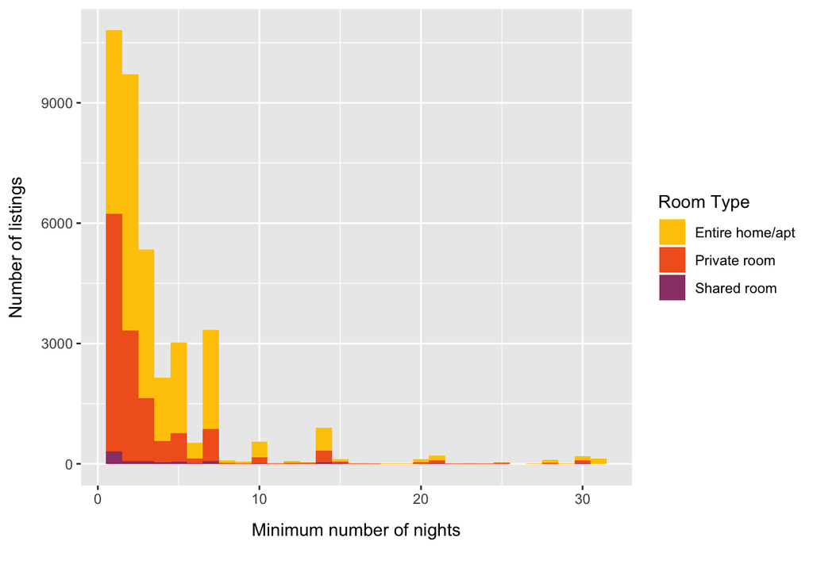

<sup>**Figure 4. Count of listings by minimum number of nights required and room type. Only includes listings with a minimum stay of 31 nights or less.**</sup>

```r
## create histogram of min nights for all observations with a min stay of 31 nights or less
minNights31 = ggplot(listingMinNights31, aes(minimum_nights))
minNights31 +
  geom_histogram(binwidth = 1, aes(fill = room_type)) +
  scale_fill_manual(values = colPalette) +
  theme(axis.title.y = element_text(margin = margin(t = 0, r = 10, b = 0, l = 0))) +
  theme(axis.title.x = element_text(margin = margin(t = 10, r = 0, b = 20, l = 0))) +
  labs(fill = "Room Type") +
  xlab(paste("Minimum number of nights")) +
  ylab("Number of listings")
```

From Figure 5 we see that while all room types are right-skewed, the distribution of minimum nights is not consistent.

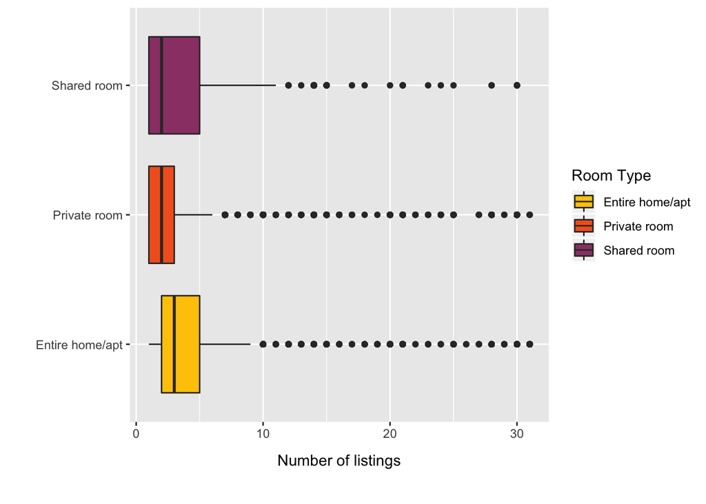

<sup>**Figure 5. Box plot of minimum number if nights required, grouped by room type. Only includes listings with a minimum stay of 31 nights or less.**</sup>

```r
minNights31Box = ggplot(listingMinNights31, aes(x = room_type, y = minimum_nights, fill = room_type))
minNights31Box +
  geom_boxplot() +
  coord_flip() +
  scale_fill_manual(values = colPalette) +
  theme(axis.title.y = element_text(margin = margin(t = 0, r = 10, b = 0, l = 0))) +
  theme(axis.title.x = element_text(margin = margin(t = 10, r = 0, b = 20, l = 0))) +
  labs(fill = "Room Type") +
  xlab(paste("")) +
  ylab("Number of listings")
```

The interquartile range (IQR) is narrowest for private rooms (Md = 2 nights), and even though there are outliers across all three room types, its upper quartile is also noticeably lower. Shared rooms also have a median of two nights, however in opposition it has the largest spread (IQR = 4 nights). This seems reasonable as people seek shared rooms for a range of reasons other than holiday-making, and the host may adjust their listing parametres to reflect the type of visitor they desire.

The entire home/apt room type has a higher median (= 3 nights) than other room types. Intuitively this may reflect practicalities on the hosts’ side, where a whole home or apartment takes more to clean, or requires the host to leave entirely. As a result they may only opt for multiple day bookings to make this worthwhile.

In summary, there is an association between the minimum number of nights and room type, with entire homes/apartments demanding slightly longer stays than private or shared rooms.

# 3 References

- Gurran, N. Phibbs, P. (2017). When Tourists Move In: How Should Urban Planners Respond to Airbnb? Journal of the American Planning Association, 83(1), 90-92. doi: 10.1080/01944363.2016.1249011
- Burnley, I. Murphy, P. (2013). Resident Location Choice in Sydney’s Peri Metropolitan Region. Journal of Urban Geography, 16 (2), 123-143. doi: 10.2747/0272-3638.16.2.123
- How will my listing’s location be shown on the map? (2019, August 25). Retrieved from https://www.airbnb.com.au/help/article/2141/how-will-my-listings-location-be-shown-on-the-map